# **Evaluating the Impact of Air Pollution on Asthma Prevalence in the U.S.: A Data-Driven Analysis**

**Authors:** Yundan Yang, Charles Zhang

[Link to our GitHub webpage](https://jJokerjokes.github.io)  
[Link to datasets (EPA official data)](https://www.epa.gov/outdoor-air-quality-data)  
[CDC Asthma Data and Surveillance](https://www.cdc.gov/asthma/asthmadata.html)  
[Link to all our datasets](https://github.com/jJokerjokes/DS_milestone)

## **Introduction & Motivation**

Asthma is a chronic respiratory condition affecting millions of people in the United States, leading to significant healthcare costs and reduced quality of life. Understanding the environmental factors contributing to asthma prevalence is crucial for public health officials, policy-makers, and researchers. Among these factors, air pollution—particularly fine particulate matter (PM2.5), nitrogen dioxide (NO2), and ground-level ozone—has been widely studied due to its potential to trigger or exacerbate respiratory issues.

From a data science perspective, leveraging large-scale environmental and health datasets can help us identify patterns, assess trends over time, and ultimately build predictive models. If certain air pollution metrics consistently correlate with higher asthma rates, these insights could guide targeted interventions and inform environmental regulations aimed at improving air quality and reducing asthma-related morbidity.

**Key Research Questions:**

- Are specific air pollutants (PM2.5, NO2, Ozone, etc.) statistically significant predictors of asthma prevalence on a county-level basis?
- How do these pollution metrics correlate with asthma prevalence over different time periods (2014–2023)?
- Can machine learning models (e.g., Random Forest) improve upon simple linear regression in predicting asthma prevalence based solely on pollution metrics?
- Do pollution metrics alone provide sufficient explanatory power, or must we consider other socioeconomic or demographic variables to enhance predictive accuracy?

By addressing these questions, we aim to produce a tutorial that clearly demonstrates the end-to-end data science lifecycle: from data extraction, cleaning, and exploratory analysis to modeling, evaluation, and interpretation of results. In doing so, we hope this analysis will serve as a reference point for environmental health studies and policy decision-making.

## **Further Reading & External Resources**

- [EPA Air Data](https://www.epa.gov/outdoor-air-quality-data) - Source of comprehensive air quality data.
- [CDC Asthma Data](https://www.cdc.gov/asthma) - Background on asthma prevalence, definitions, and health impact.
- [Basic Concepts in Regression Analysis](https://towardsdatascience.com/introduction-to-regression-analysis-26fad71c797f) - A primer on regression techniques for those new to the field.
- [Random Forest Tutorial](https://towardsdatascience.com/random-forest-in-python-24d0893d51c0) - Introduction to Random Forest modeling approach.

## **Project Outline**

1. **Data Acquisition & Merging**:  
   Load and combine county-level annual air quality data (EPA) and county-level asthma prevalence data (CDC) for the years 2014 to 2023.
2. **Data Cleaning & Harmonization**:  
   Although the initial datasets are fairly tidy, we will ensure correct data types, handle any missing or inconsistent values, and confirm consistent county identifiers.
3. **Exploratory Data Analysis (EDA)**:
   - Compute summary statistics of pollution metrics and asthma rates.
   - Visualize nationwide trends, identify the most frequent pollution metrics, and highlight temporal variations.
4. **Modeling**:
   - Implement both linear regression and Random Forest models to predict asthma prevalence.
   - Compare model performance to determine whether more complex models improve predictive power.
5. **Results Interpretation & Policy Implications**:
   - Discuss how model results inform our understanding of pollution and asthma.
   - Highlight limitations and suggest directions for future work (e.g., incorporating socioeconomic or climatic factors).

## **Collaboration Plan**

We will continue to use Google Colab to streamline our collaborative efforts, enabling frequent code sharing, result review, and discussion. Given that we live near each other, we can hold periodic in-person meetings to refine our approach, interpret intermediate results, and ensure alignment with the project’s objectives.

## **Data Extraction, Transform, and Load (ETL)**

Our primary datasets are sourced from:

- **EPA Air Quality Reports (2014–2023)**: Annual county-level air pollution indicators, including PM2.5, NO2, ozone, and other pollutants.
- **CDC National Asthma Prevalence Data (2014–2023)**: County-level asthma rates, measured as the percentage of individuals diagnosed with asthma.

**Data Format & Initial Observations**:

- Both datasets are available in CSV format.
- Each record corresponds to a U.S. county identified by unique county codes (e.g., FIPS codes).
- The EPA data includes metrics like “Days PM2.5,” “Days Ozone,” etc., representing the number of days per year exceeding certain pollutant thresholds.
- The CDC data provides annual asthma prevalence percentages per county.

```python
import pandas as pd
import numpy as np
import matplotlib.pyplot as plt
import seaborn as sns
from google.colab import drive
drive.mount('/content/drive')
```

# **Extraction, Transform, and Load**

In this project, data is sourced from the U.S. Environmental Protection Agency (EPA), featuring annual air quality reports from 2014 to 2023, and national asthma prevalence records spanning the same period. The extraction phase involves loading these datasets, available in CSV format, which detail various pollution metrics and health data by county. During transformation, the data undergoes cleaning, alignment, and consolidation into a single analytical framework, which includes merging pollution data with asthma prevalence on a county basis. This harmonized dataset enables a comprehensive year-over-year analysis to investigate correlations between air quality and asthma occurrences. The datasets were already tidy, thus there was no need to clean up the dataframes

```python
%cd /content/drive/MyDrive/
# Load air quality datasets for each year
df_2014 = pd.read_csv("annual_aqi_by_county_2014.csv")
df_2015 = pd.read_csv("annual_aqi_by_county_2015.csv")
df_2016 = pd.read_csv("annual_aqi_by_county_2016.csv")
df_2017 = pd.read_csv("annual_aqi_by_county_2017.csv")
df_2018 = pd.read_csv("annual_aqi_by_county_2018.csv")
df_2019 = pd.read_csv("annual_aqi_by_county_2019.csv")
df_2020 = pd.read_csv("annual_aqi_by_county_2020.csv")
df_2021 = pd.read_csv("annual_aqi_by_county_2021.csv")
df_2022 = pd.read_csv("annual_aqi_by_county_2022.csv")
df_2023 = pd.read_csv("annual_aqi_by_county_2023.csv")
# Load the nationwide asthma prevalence data
asthma_national_data = pd.read_csv("current-asthma-prevalence-by-county-2015_2022.csv", encoding="ISO-8859-1")
```

```
/content/drive/MyDrive
```

```python
# Concatenate all years and sum the pollution data by county
all_years_data = pd.concat([df_2014, df_2015, df_2016, df_2017, df_2018,
                            df_2019, df_2020, df_2021, df_2022])
# Extract year information and convert to integer type
asthma_national_data["YEARS"] = asthma_national_data["YEARS"].str.extract(r"(\d{4})").astype(int)
asthma_2015_2016 = asthma_national_data[asthma_national_data["YEARS"].isin([2015, 2016])]
asthma_2017_2018 = asthma_national_data[asthma_national_data["YEARS"].isin([2017, 2018])]
asthma_2019_2020 = asthma_national_data[asthma_national_data["YEARS"].isin([2019, 2020])]
asthma_2021_2022 = asthma_national_data[asthma_national_data["YEARS"].isin([2021, 2022])]
```

### **Data Overview**:

```python
all_years_data.head()
```

|  | State | County | Year | Days with AQI | Good Days | Moderate Days | Unhealthy for Sensitive Groups Days | Unhealthy Days | Very Unhealthy Days | Hazardous Days | Max AQI | 90th Percentile AQI | Median AQI | Days CO | Days NO2 | Days Ozone | Days PM2.5 | Days PM10 |
| --- | --- | --- | --- | --- | --- | --- | --- | --- | --- | --- | --- | --- | --- | --- | --- | --- | --- | --- |
| 0 | Alabama | Baldwin | 2014 | 280 | 209 | 69 | 2 | 0 | 0 | 0 | 112 | 62 | 40 | 0 | 0 | 185 | 95 | 0 |
| 1 | Alabama | Clay | 2014 | 114 | 64 | 50 | 0 | 0 | 0 | 0 | 73 | 59 | 48 | 0 | 0 | 0 | 114 | 0 |
| 2 | Alabama | Colbert | 2014 | 284 | 224 | 60 | 0 | 0 | 0 | 0 | 87 | 56 | 39 | 0 | 0 | 187 | 97 | 0 |
| 3 | Alabama | DeKalb | 2014 | 360 | 281 | 79 | 0 | 0 | 0 | 0 | 90 | 57 | 40 | 0 | 0 | 273 | 87 | 0 |
| 4 | Alabama | Elmore | 2014 | 245 | 224 | 21 | 0 | 0 | 0 | 0 | 84 | 49 | 36 | 0 | 0 | 245 | 0 | 0 |

```python
asthma_national_data.head()
```

|  | COUNTY | YEARS | STRATA | AGE GROUP | CURRENT PREVALENCE | 95% CONFIDENCE INTERVAL | COUNTIES GROUPED | COMMENT |
| --- | --- | --- | --- | --- | --- | --- | --- | --- |
| 0 | California | 2015 | Total population | All ages | 8.7 | (8.19.3) | NaN | NaN |
| 1 | Alameda | 2015 | Total population | All ages | 9.1 | (5.912.2) | NaN | NaN |
| 2 | Alpine | 2015 | Total population | All ages | 9.3 | (4.114.6) | Alpine, Amador, Calaveras, Inyo, Mariposa, Mon... | NaN |
| 3 | Amador | 2015 | Total population | All ages | 9.3 | (4.114.6) | Alpine, Amador, Calaveras, Inyo, Mariposa, Mon... | NaN |
| 4 | Butte | 2015 | Total population | All ages | 9.4 | (3.815.1) | NaN | Estimate is statistically unstable. Caution is... |

```python
print(all_years_data.info())
print(asthma_national_data.info())
```

```
<class 'pandas.core.frame.DataFrame'>
Index: 9195 entries, 0 to 1002
Data columns (total 18 columns):
 #   Column                               Non-Null Count  Dtype
---  ------                               --------------  -----
 0   State                                9195 non-null   object
 1   County                               9195 non-null   object
 2   Year                                 9195 non-null   int64
 3   Days with AQI                        9195 non-null   int64
 4   Good Days                            9195 non-null   int64
 5   Moderate Days                        9195 non-null   int64
 6   Unhealthy for Sensitive Groups Days  9195 non-null   int64
 7   Unhealthy Days                       9195 non-null   int64
 8   Very Unhealthy Days                  9195 non-null   int64
 9   Hazardous Days                       9195 non-null   int64
 10  Max AQI                              9195 non-null   int64
 11  90th Percentile AQI                  9195 non-null   int64
 12  Median AQI                           9195 non-null   int64
 13  Days CO                              9195 non-null   int64
 14  Days NO2                             9195 non-null   int64
 15  Days Ozone                           9195 non-null   int64
 16  Days PM2.5                           9195 non-null   int64
 17  Days PM10                            9195 non-null   int64
dtypes: int64(16), object(2)
memory usage: 1.3+ MB
None
<class 'pandas.core.frame.DataFrame'>
RangeIndex: 1652 entries, 0 to 1651
Data columns (total 8 columns):
 #   Column                   Non-Null Count  Dtype
---  ------                   --------------  -----
 0   COUNTY                   1652 non-null   object
 1   YEARS                    1652 non-null   int64
 2   STRATA                   1652 non-null   object
 3   AGE GROUP                1652 non-null   object
 4   CURRENT PREVALENCE       1067 non-null   float64
 5   95% CONFIDENCE INTERVAL  1067 non-null   object
 6   COUNTIES GROUPED         476 non-null    object
 7   COMMENT                  995 non-null    object
dtypes: float64(1), int64(1), object(6)
memory usage: 103.4+ KB
None
```

We performed an initial check to ensure the datasets are tidy:

Pollution Data: The EPA pollution datasets were complete, with no missing values observed.

Data Types: Numerical fields (e.g., pollution metrics, asthma rates) were correctly parsed as floats or integers, while categorical fields (e.g., county identifiers) were strings.

```python
asthma_national_data['CURRENT PREVALENCE'] = asthma_national_data.groupby("COUNTY")["CURRENT PREVALENCE"].transform(lambda x: x.fillna(x.mean()))
print(f"Now there are {asthma_national_data['CURRENT PREVALENCE'].isna().sum()} NaN")
print(asthma_national_data.info())
print(asthma_national_data.describe())
```

```
Now there are 0 NaN
<class 'pandas.core.frame.DataFrame'>
RangeIndex: 1652 entries, 0 to 1651
Data columns (total 8 columns):
 #   Column                   Non-Null Count  Dtype
---  ------                   --------------  -----
 0   COUNTY                   1652 non-null   object
 1   YEARS                    1652 non-null   int64
 2   STRATA                   1652 non-null   object
 3   AGE GROUP                1652 non-null   object
 4   CURRENT PREVALENCE       1652 non-null   float64
 5   95% CONFIDENCE INTERVAL  1067 non-null   object
 6   COUNTIES GROUPED         476 non-null    object
 7   COMMENT                  995 non-null    object
dtypes: float64(1), int64(1), object(6)
memory usage: 103.4+ KB
None
             YEARS  CURRENT PREVALENCE
count  1652.000000         1652.000000
mean   2018.000000           10.512454
std       2.236745            3.114316
min    2015.000000            0.300000
25%    2016.500000            8.400000
50%    2018.000000           10.260000
75%    2019.500000           12.500000
max    2021.000000           33.400000
```

The datasets are now ready for further analysis, ensuring meaningful patterns can be identified without data quality concerns.

# **Exploratory Analysis & Data Visualization**

Before diving into specific analyses, let's provide an overview of the data. With the combined dataset ready, we now examine temporal and geographic variations in pollution levels and asthma rates. Understanding these baseline distributions lays the groundwork for subsequent modeling steps, where we will attempt to identify which pollutants serve as the strongest predictors of asthma prevalence.

The following sections focus on:

- Frequency and distribution of different pollutants across U.S. counties.
- Trends over multiple years.
- Preliminary correlations between pollution metrics and asthma prevalence (this will be detailed after establishing baseline patterns).

## **Frequency of Pollution**

The steps in the analysis are as follows:

- Definition of Metrics: The pollution metrics are defined to capture the frequency of specific pollutants across the dataset.
- County-Level Averages: The number of pollution days for each metric is calculated for each county by averaging over all years in the dataset.
- Overall Averages: The overall average pollution frequency across all counties is calculated to provide a nationwide view of pollution trends for each metric.
- Visualization:
  1. Bar Chart: Displays the overall average number of days per year for each pollution type, highlighting which pollutants were most frequently recorded.
  2. Pie Chart: Illustrates the proportional distribution of pollution frequency among the five pollution types, offering a visual comparison of their relative occurrence.

This dual visualization approach provides a comprehensive understanding of pollution frequency across the observed period, allowing for targeted environmental and health policy decisions. The findings also underscore the need for further investigation into the high frequency of ozone pollution days.

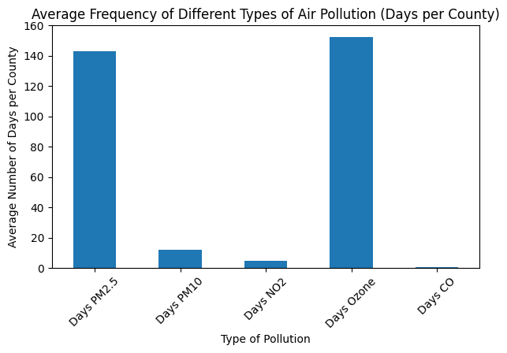

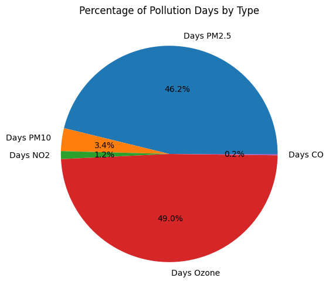

```python
# Define columns representing pollution days
pollution_columns = ["Days PM2.5", "Days PM10", "Days NO2", "Days Ozone", "Days CO"]

# Calculate the average pollution days per county for each type
average_pollution_per_county = all_years_data.groupby("County")[pollution_columns].mean()

# Calculate the overall average pollution days across all counties for each pollution type
overall_average_pollution = average_pollution_per_county.mean()

# Plot the pollution frequency as a bar chart
plt.figure(figsize=(7, 4))
overall_average_pollution.plot(kind='bar')
plt.title("Average Frequency of Different Types of Air Pollution (Days per County)")
plt.xlabel("Type of Pollution")
plt.ylabel("Average Number of Days per County")
plt.xticks(rotation=45)
plt.show()
#pie chart
total_pollution_days = all_years_data[pollution_columns].sum()
pollution_percentage = (total_pollution_days / total_pollution_days.sum()) * 100
pollution_percentage.plot(kind='pie', autopct="%1.1f%%", figsize=(6, 6))
plt.title("Percentage of Pollution Days by Type")
plt.ylabel("")  # Remove default y-axis label
plt.show()
```

From the bar chart, we observe that PM2.5 and Ozone days are, on average, significantly more frequent than PM10, NO2, and CO days. This could be related to a combination of factors including industrial emissions, vehicle exhaust, and climatic conditions fostering photochemical reactions that produce ground-level ozone.

Regional differences or seasonal patterns might also influence these frequencies. For instance, some regions might experience more stagnant air episodes, leading to accumulation of PM2.5, while others could have industrial sources contributing to ozone formation. In the subsequent sections, we will:

- Break down these pollution metrics by time period to see if there is a trend of improvement or worsening conditions.
- Eventually correlate these pollution levels with asthma prevalence to determine if these high-frequency pollutants (like PM2.5 and Ozone) align with higher asthma rates.

In the subsequent sections, we will:

- Break down these pollution metrics by time period to see if there is a trend of improvement or worsening conditions.
- Eventually correlate these pollution levels with asthma prevalence to determine if these high-frequency pollutants (like PM2.5 and Ozone) align with higher asthma rates.

## **Yearly Trend of Pollution Frequency**

**Implications**:  
This long-term view suggests that while some pollutants (like NO2 and CO) remain at low frequencies, others (notably Ozone and PM2.5) are more entrenched. Understanding these persistent trends sets the stage for linking pollution data to health outcomes. In upcoming sections, we will overlay these temporal insights with asthma prevalence data to investigate whether stable or rising frequencies of certain pollutants correspond to increased asthma rates.

For more on national trends in emissions and air quality standards, see [EPA’s Air Quality Trends](https://www.epa.gov/air-trends).

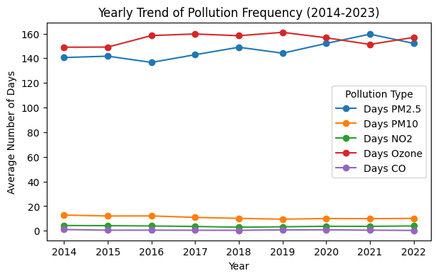

```python
annual_pollution = all_years_data.groupby("Year")[pollution_columns].mean()
annual_pollution.plot(figsize=(7, 4), marker='o')
plt.title("Yearly Trend of Pollution Frequency (2014-2023)")
plt.xlabel("Year")
plt.ylabel("Average Number of Days")
plt.legend(title="Pollution Type")
plt.show()
```

## **Distribution of Pollution Frequency for Each Type**

The box plot below shows the statistical distribution (median, interquartile range, outliers) of pollution frequency for each pollutant type (PM2.5, PM10, NO2, Ozone, CO) across all counties:

As we proceed, these insights will help us consider whether to treat outliers differently, apply transformations, or incorporate regional dummy variables in the predictive modeling stage.

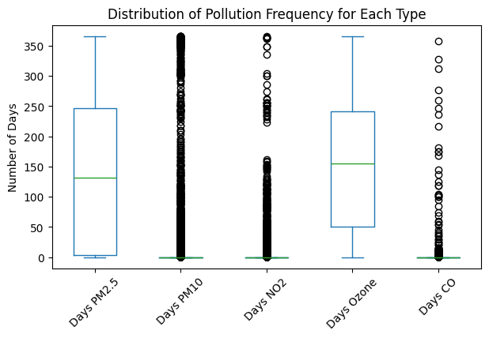

```python
all_years_data[pollution_columns].plot(kind='box', figsize=(7, 4))
plt.title("Distribution of Pollution Frequency for Each Type")
plt.ylabel("Number of Days")
plt.xticks(rotation=45)
plt.show()
```

## **Investigating the Relationship Between Asthma Prevalence and Pollution Levels**

To deepen our analysis, we now shift from understanding pollution frequency alone to examining its relationship with asthma prevalence. Building on our exploratory insights, we seek to determine whether higher pollutant levels consistently appear alongside elevated asthma rates. If a robust relationship exists, it could guide targeted environmental regulations or healthcare interventions.

In this section, we will:

- Identify “asthma hotspots” – counties with the highest asthma prevalence across the studied years.
- Compare these hotspots with the most polluted counties to see if there is a visible overlap or pattern.
- Set the stage for a more formal modeling approach (e.g., regression, Random Forest) to quantify the strength of any observed relationships.

## **Identifying Asthma Hotspots**

*Note:* While identifying these hotspots is valuable, it only provides a starting point. High asthma prevalence in a county does not automatically confirm that pollution is the primary driver. Next, we will compare these findings with pollution metrics to discern any patterns.

```
        COUNTY  CURRENT PREVALENCE
0        Butte                33.4
1         Kern                26.0
2       Solano                23.8
3         Lake                22.9
4       Sutter                22.5
5       Merced                22.4
6   Santa Cruz                22.4
7        Kings                21.4
8     Imperial                20.9
9   Stanislaus                20.6
10     Alameda                19.4
11        Inyo                19.0
12    Tuolumne                19.0
13   Calaveras                19.0
14    Mariposa                19.0
15      Amador                19.0
16      Alpine                19.0
17        Mono                19.0
18        Yolo                18.8
19      Tulare                18.4
```

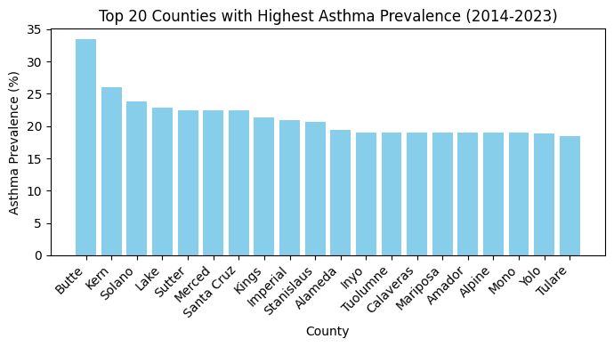

```python
# Calculate the maximum prevalence for each county across all years
max_asthma_prevalence = asthma_national_data.groupby("COUNTY")["CURRENT PREVALENCE"].max().reset_index()

# Sort the data by asthma prevalence in descending order
top_asthma_prevalence_counties = max_asthma_prevalence.sort_values(by="CURRENT PREVALENCE", ascending=False)

# Display the top 10 counties with the highest asthma prevalence
top_asthma_prevalence_counties.reset_index(drop=True, inplace=True)
print(top_asthma_prevalence_counties.head(20))
plt.figure(figsize=(7, 4))
plt.bar(top_asthma_prevalence_counties.head(20)["COUNTY"], top_asthma_prevalence_counties.head(20)["CURRENT PREVALENCE"], color="skyblue")
plt.title("Top 20 Counties with Highest Asthma Prevalence (2014-2023)")
plt.ylabel("Asthma Prevalence (%)")
plt.xlabel("County")
plt.xticks(rotation=45, ha="right")
plt.tight_layout()
plt.show()
```

## **The Most Polluted Sites**

```
            Days PM2.5  Days PM10  Days NO2  Days Ozone  Days CO  \
County
Jefferson        18803        124        77       16793        0
Washington       14938        128       125       20148        0
Montgomery       17220         14        24        8734       25
Lake             10257        491        29       12518       12
Jackson          10345        289       569        8191        1
Clark             7822        102        93       10739        1
Hamilton         10865          0        71        7426        0
Franklin         10775          8       654        6909        0
Madison           9286        270         0        8283        0
Douglas           8403         78         0        6273        2
Adams             8110        312       559        5279        5
Monroe            6917        338        12        6784        1
Union             9228        847       268        3496        2
Columbia          6735          0         0        6842        0
Knox              2276         79         0       11162        0
Cass              5293       3241        32        4836        0
Orange            7161         29       133        5797        2
Kent              6583          7        10        6367        4
Cumberland        8164         40        92        4672        0
Polk              5025          6        46        7830        0

            Total Pollution Days
County
Jefferson                  35797
Washington                 35339
Montgomery                 26017
Lake                       23307
Jackson                    19395
Clark                      18757
Hamilton                   18362
Franklin                   18346
Madison                    17839
Douglas                    14756
Adams                      14265
Monroe                     14052
Union                      13841
Columbia                   13577
Knox                       13517
Cass                       13402
Orange                     13122
Kent                       12971
Cumberland                 12968
Polk                       12907
```

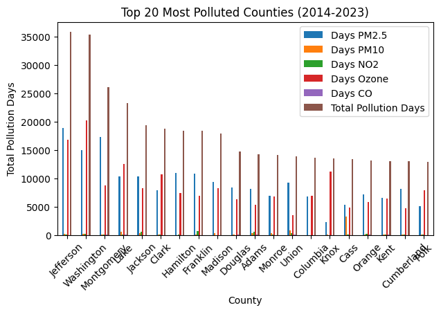

```python
pollution_features = ["Days PM2.5", "Days PM10", "Days NO2", "Days Ozone", "Days CO"]

# Calculate total pollution days by county if not already done in previous sections
if "Total Pollution Days" not in all_years_data.columns:
    city_pollution_sum = all_years_data.groupby("County")[pollution_features].sum()
    city_pollution_sum["Total Pollution Days"] = city_pollution_sum.sum(axis=1)
else:
    city_pollution_sum = all_years_data.groupby("County")[pollution_features].sum()
    city_pollution_sum["Total Pollution Days"] = all_years_data.groupby("County")["Total Pollution Days"].first()

# Sort cities by total pollution days in descending order to find the most polluted cities
most_polluted_cities = city_pollution_sum.sort_values(by="Total Pollution Days", ascending=False)
print(most_polluted_cities.head(20))
most_polluted_cities.head(20).plot(kind='bar', figsize=(7, 4))
plt.title("Top 20 Most Polluted Counties (2014-2023)")
plt.ylabel("Total Pollution Days")
plt.xlabel("County")
plt.xticks(rotation=45)
plt.show()
```

### **Preliminary Comparison of Hotspots and Pollution Levels**

After identifying the counties with the highest asthma prevalence and those with the most pollution days, we see that they do not perfectly align. While some highly polluted counties do not exhibit exceptionally high asthma prevalence, others with high asthma rates do not top the pollution charts.

**Interpreting These Findings**:

- **Complex Interactions**: Asthma prevalence is influenced by a multitude of factors, including genetics, socioeconomic status, indoor air quality, healthcare access, smoking rates, and more. Thus, pollution alone may not fully explain asthma variations at the county level.
- **Type vs. Quantity of Pollution**: Even if total pollution days are high, the mix of pollutants might matter. A county could have many days of PM10 but few days of Ozone or PM2.5, which may not strongly correlate with asthma.
- **Temporal and Regional Differences**: Asthma prevalence data might not perfectly overlap in time or granularity with pollution measurements, and regional patterns (e.g., urban vs. rural) may come into play.

**Next Steps – Moving towards Modeling:**  
The preliminary observations suggest that any potential relationship between pollution and asthma prevalence might be subtle, nonlinear, or influenced by additional variables. To clarify this relationship, we plan to:

- Calculate correlation coefficients between each pollutant metric and asthma prevalence.
- Experiment with a range of regression and machine learning models to capture complex relationships.
- Introduce extra explanatory variables (e.g., population density, healthcare access) to improve predictive accuracy.

By employing these modeling strategies, we aim to determine the true predictive power of pollution metrics and understand what additional factors are needed to explain variations in asthma prevalence.

## **Identifying Overlapping Counties with High Pollution and Asthma Prevalence**

Before we fully commit to advanced modeling, it’s useful to consider a simpler empirical check: do the most polluted counties also tend to have the highest asthma prevalence? To explore this, we compare the top 100 counties in terms of asthma prevalence to the top 100 counties in terms of pollution levels.

A significant overlap between these two groups could signal a direct, observable association, guiding our subsequent modeling efforts. Conversely, a lack of substantial overlap might reinforce our earlier notion that other, less obvious factors influence asthma rates, prompting us to refine our modeling approach and incorporate additional variables.

```python
# Extract the top 100 counties for asthma prevalence
top_100_asthma_counties = top_asthma_prevalence_counties.head(100)["COUNTY"]

# Extract the top 100 counties for pollution
top_100_polluted_counties = most_polluted_cities.head(100).index

# Find the intersection of the two lists
intersecting_counties = set(top_100_asthma_counties).intersection(set(top_100_polluted_counties))

# Display the intersecting counties
print(f"Intersecting Counties (Top 100 Asthma & Top 100 Pollution): {intersecting_counties}")

# Convert to a list or DataFrame if needed for further analysis
intersecting_counties_list = list(intersecting_counties)
intersecting_counties_df = pd.DataFrame(intersecting_counties_list, columns=["COUNTY"])
intersecting_counties_df
```

```
Intersecting Counties (Top 100 Asthma & Top 100 Pollution): {'Santa Cruz', 'Kings', 'Butte', 'Orange', 'Lake'}
```

|  | COUNTY |
| --- | --- |
| 0 | Santa Cruz |
| 1 | Kings |
| 2 | Butte |
| 3 | Orange |
| 4 | Lake |

The limited overlap between these two groups suggests that a high pollution burden does not necessarily coincide with the highest asthma prevalence rates at the county level. While a few counties (e.g., Lake, Butte, Orange, Kings, Santa Cruz) appear in both lists, the majority of high-asthma counties are not among the highest-pollution counties, and vice versa.

**Why might this be the case?**

- **Multifactorial Nature of Asthma**: Asthma prevalence is influenced by a range of factors including genetic predisposition, indoor allergens, healthcare access, socioeconomic conditions, and smoking rates, not just outdoor pollution.
- **Pollutant-Specific Effects**: Certain pollutants may correlate more strongly with asthma than others. Summarizing all pollution types into a single metric might dilute specific influential pollutants.
- **Geographic and Temporal Nuances**: County-level data may be too coarse, or the timing of exposure and asthma manifestation may not align simply with annual aggregates of pollution days.

## **Graph presentation of Total Pollution Days and Asthma Prevalence**

Key observations from the scatter plot include:

Most counties are clustered toward the lower end of total pollution days, with fewer counties experiencing extremely high levels.

Asthma prevalence does not exhibit a clear increasing trend with total pollution days. This suggests that total pollution days alone may not strongly correlate with asthma prevalence across counties.

Some counties with high pollution days display moderate asthma prevalence, while counties with fewer pollution days also exhibit varying asthma prevalence levels.

This visualization underscores the complexity of the relationship between air pollution and asthma, indicating that additional factors may influence asthma prevalence. Further modeling and analysis are necessary to explore these relationships in greater detail.

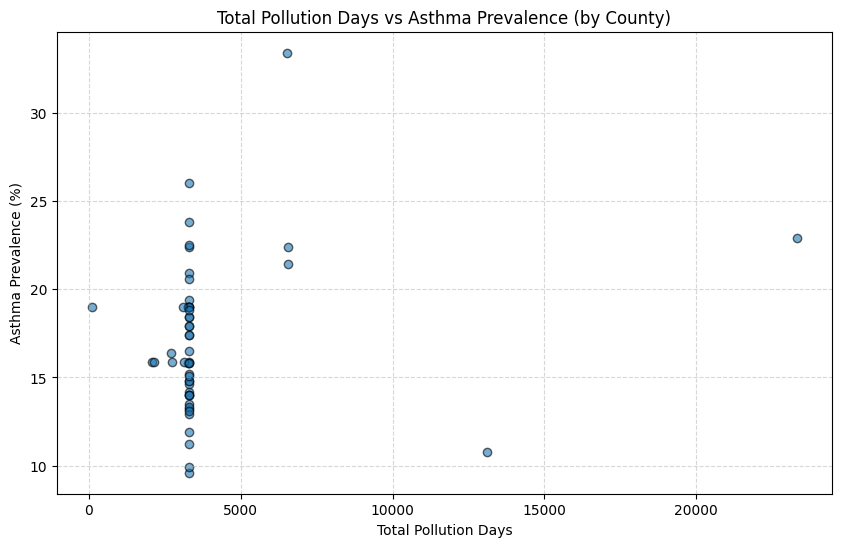

```python
# Calculate total pollution days by county
city_pollution_sum = all_years_data.groupby("County")[pollution_features].sum()
city_pollution_sum["total_pollution_days"] = city_pollution_sum.sum(axis=1)

# Calculate maximum asthma prevalence by county
max_asthma_prevalence = asthma_national_data.groupby("COUNTY")["CURRENT PREVALENCE"].max().reset_index()

# Merge pollution and asthma prevalence data on county name
pollution_asthma_df = city_pollution_sum.merge(max_asthma_prevalence, left_index=True, right_on="COUNTY")

# Scatter plot for Total Pollution Days vs Asthma Prevalence
plt.figure(figsize=(10, 6))
plt.scatter(pollution_asthma_df['total_pollution_days'], pollution_asthma_df['CURRENT PREVALENCE'], alpha=0.6, edgecolor='k')

# Setting labels and title
plt.xlabel('Total Pollution Days')
plt.ylabel('Asthma Prevalence (%)')
plt.title('Total Pollution Days vs Asthma Prevalence (by County)')

plt.grid(True, linestyle='--', alpha=0.5)
plt.show()
```

## **Graph presentation of each pollution feature**

This section examines the relationship between individual pollution features and asthma prevalence percentages across counties in the United States.

While certain pollutants may correlate with asthma prevalence in specific cases, the overall trends indicate that asthma rates are influenced by multiple factors. Further analysis incorporating socio-economic and demographic data may provide deeper insights into the drivers of asthma prevalence.

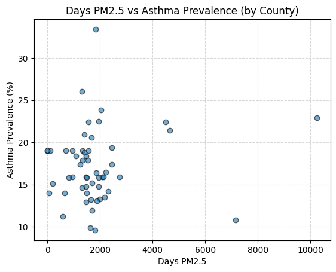

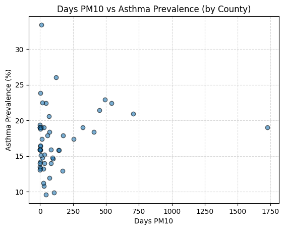

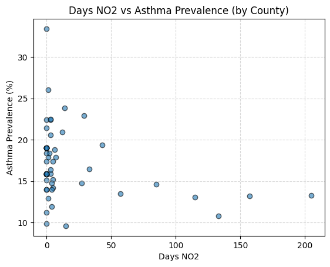

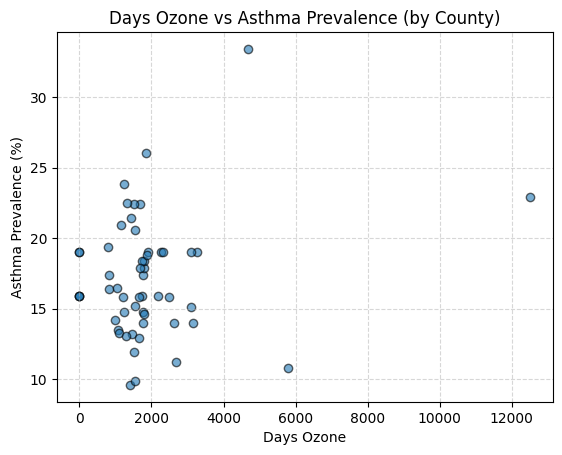

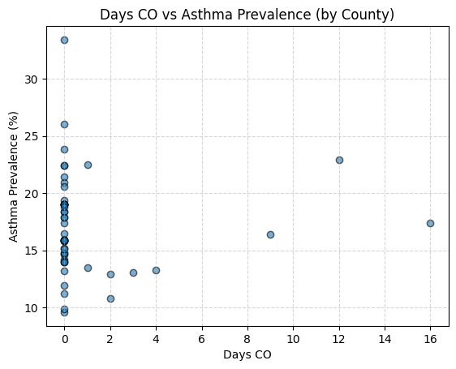

```python
for feature in pollution_features:
  plt.scatter(pollution_asthma_df[feature], pollution_asthma_df['CURRENT PREVALENCE'], alpha=0.6, edgecolor='k')
  plt.xlabel(feature)
  plt.ylabel('Asthma Prevalence (%)')
  plt.title(f'{feature} vs Asthma Prevalence (by County)')
  plt.grid(True, linestyle='--', alpha=0.5)
  plt.show()
```

**Key Observations:**

- **No Clear Trend**: Asthma prevalence does not increase linearly with total pollution days. Most counties cluster at relatively moderate asthma prevalence levels, regardless of pollution days.
- **Outliers and Variability**: Some counties with high total pollution days do not exhibit proportionally high asthma prevalence, and vice versa. This suggests that total pollution alone may not be a strong predictor.

**Implications**:  
These findings underscore the complexity of the relationship. Asthma prevalence might depend on specific pollutant types rather than the total number of pollution days. Alternatively, socioeconomic or healthcare factors may moderate the impact of pollution on respiratory health.

To delve deeper, we will:

- Examine relationships between individual pollutants (e.g., PM2.5, Ozone) and asthma prevalence to see if any particular pollutant correlates more strongly.
- Compute correlation coefficients (e.g., Pearson, Spearman) and consider fitting regression models to quantify the strength of association.
- Consider adding other variables (demographics, healthcare access) to the model to control for confounding factors.

This incremental approach will help us move from simple visual inspection to a more rigorous, data-driven assessment of the pollution-asthma relationship.

# **Modeling the Relationship Between Pollution and Asthma Prevalence**

In this section, we aim to use statistical and machine learning models to further examine the potential relationship between air pollution levels and asthma prevalence. Building upon the prior analysis of overlapping counties, the modeling process will provide a quantitative framework to assess whether air pollution metrics can reliably predict asthma prevalence. This approach seeks to validate or challenge the hypothesis that higher pollution levels contribute to increased asthma rates.

## **Regression Analysis of Pollution Impact on Asthma Prevalence**

This analysis performs a direct linear regression analysis to explore the relationship between air pollution metrics and asthma prevalence across different counties. The process involves merging pollution data with asthma records, followed by applying a regression model to determine how variables we identify in the ealier section contribute to asthma rates. The result would varify or deny our assumption

```python
from sklearn.model_selection import train_test_split
from sklearn.metrics import r2_score, mean_squared_error
from sklearn.linear_model import LinearRegression
pollution_features = ["Days PM2.5", "Days PM10", "Days NO2", "Days Ozone", "Days CO"]
county_pollution_sum = all_years_data.groupby("County")[pollution_features].sum().reset_index()

# Load and prepare the latest asthma prevalence data
asthma_national_data = pd.read_csv("current-asthma-prevalence-by-county-2015_2022.csv", encoding="ISO-8859-1")
asthma_national_data["YEARS"] = asthma_national_data["YEARS"].str.extract(r"(\d{4})").astype(int)
asthma_latest_data = asthma_national_data.groupby("COUNTY")["CURRENT PREVALENCE"].max().reset_index()

# Merge pollution data with asthma prevalence data
merged_data_all_years = pd.merge(county_pollution_sum, asthma_latest_data, left_on="County", right_on="COUNTY")

# Define independent variables (top correlated pollution features) and dependent variable (asthma prevalence)
X = merged_data_all_years[pollution_features]
y = merged_data_all_years["CURRENT PREVALENCE"]

# Split the data into training and testing sets
X_train, X_test, y_train, y_test = train_test_split(X, y, test_size=0.2, random_state=42)

# Fit a linear regression model
model = LinearRegression()
model.fit(X_train, y_train)

# Make predictions on the test set
y_pred = model.predict(X_test)

# Evaluate the model
r2 = r2_score(y_test, y_pred)
mse = mean_squared_error(y_test, y_pred)
coefficients = pd.DataFrame({"Feature": pollution_features, "Coefficient": model.coef_})

# Output the results
print("R^2 Score:", r2)
print("Mean Squared Error:", mse)
print("Coefficients:")
coefficients.sort_values(by="Coefficient", ascending=False)
```

```
R^2 Score: 0.058549884303971234
Mean Squared Error: 32.80665771760324
Coefficients:
```

|  | Feature | Coefficient |
| --- | --- | --- |
| 4 | Days CO | 0.039929 |
| 1 | Days PM10 | 0.002212 |
| 0 | Days PM2.5 | 0.000299 |
| 3 | Days Ozone | 0.000117 |
| 2 | Days NO2 | -0.031291 |

## **Analyzing the Lagged Impact of Air Pollution on Asthma Prevalence**

```python
# Calculate 5-year cumulative pollution data by county
# Split data into 5-year periods: 2014-2018 and 2019-2023
pollution_2014_2018 = all_years_data[all_years_data['Year'].isin([2014, 2015, 2016, 2017, 2018])]
pollution_2019_2023 = all_years_data[all_years_data['Year'].isin([2019, 2020, 2021, 2022, 2023])]

# Sum pollution levels across each 5-year period by county
pollution_2014_2018_sum = pollution_2014_2018.groupby("County")[pollution_features].sum().reset_index()
pollution_2019_2023_sum = pollution_2019_2023.groupby("County")[pollution_features].sum().reset_index()

# Load asthma prevalence data
asthma_national_data = pd.read_csv("current-asthma-prevalence-by-county-2015_2022.csv", encoding="ISO-8859-1")
asthma_national_data["YEARS"] = asthma_national_data["YEARS"].str.extract(r"(\d{4})").astype(int)

# Get maximum asthma prevalence for each county in each 5-year period
asthma_2014_2018 = asthma_national_data[asthma_national_data["YEARS"].isin([2015, 2016, 2017, 2018])].groupby("COUNTY")["CURRENT PREVALENCE"].max().reset_index()
asthma_2019_2023 = asthma_national_data[asthma_national_data["YEARS"] >= 2019].groupby("COUNTY")["CURRENT PREVALENCE"].max().reset_index()

# Merge pollution and asthma data for each 5-year period
data_2014_2018 = pd.merge(pollution_2014_2018_sum, asthma_2014_2018, left_on="County", right_on="COUNTY")
data_2019_2023 = pd.merge(pollution_2019_2023_sum, asthma_2019_2023, left_on="County", right_on="COUNTY")

# Perform linear regression for each 5-year period and calculate metrics
def perform_regression_analysis(data, period):
    X = data[pollution_features]
    y = data["CURRENT PREVALENCE"]

    # Split into train and test sets
    X_train, X_test, y_train, y_test = train_test_split(X, y, test_size=0.2, random_state=42)

    # Fit the model
    model = LinearRegression()
    model.fit(X_train, y_train)

    # Predictions and evaluation
    y_pred = model.predict(X_test)
    r2 = r2_score(y_test, y_pred)
    mse = mean_squared_error(y_test, y_pred)
    coefficients = pd.DataFrame({"Feature": pollution_features, "Coefficient": model.coef_})

    # Display results
    print(f"Regression Results for {period}:")
    print("R^2 Score:", r2)
    print("Mean Squared Error:", mse)
    print("Coefficients:")
    print(coefficients.sort_values(by="Coefficient", ascending=False))
    print("\n")

# Run regression analysis for each period
perform_regression_analysis(data_2014_2018, "2014-2018")
perform_regression_analysis(data_2019_2023, "2019-2023")
```

```
Regression Results for 2014-2018:
R^2 Score: 0.06698299798150953
Mean Squared Error: 15.091742779756936
Coefficients:
      Feature  Coefficient
4     Days CO     0.600841
1   Days PM10     0.003042
0  Days PM2.5     0.000049
3  Days Ozone    -0.000017
2    Days NO2    -0.047075


Regression Results for 2019-2023:
R^2 Score: -0.08603627770362032
Mean Squared Error: 10.112882601770439
Coefficients:
      Feature  Coefficient
4     Days CO     0.052668
1   Days PM10     0.004783
3  Days Ozone     0.001445
0  Days PM2.5    -0.001025
2    Days NO2    -0.066798
```

The regression analyses, both straightforward and lagged, suggest that simple linear models and direct cumulative exposure metrics do not provide strong explanatory power for asthma prevalence. The low R² scores and inconsistent coefficients indicate that if a relationship exists, it may be more subtle, nonlinear, or reliant on additional interacting factors not captured by our current approach.

**Transition to More Advanced Modeling**:  
To further investigate the potential complexities and nonlinearities in the relationship between air pollution and asthma prevalence, we will now apply a Random Forest model. Unlike linear regression, Random Forest can capture nonlinear interactions and complex patterns in the data. By using this ensemble machine learning technique, we aim to determine whether a more flexible model can uncover meaningful predictive signals that linear methods failed to detect.

In the next section, we implement the Random Forest model to evaluate its performance, assess feature importances, and see if it can provide a better understanding of how different pollutants might influence asthma prevalence.

# **Non-linear regression model**

Given the low R² score observed in the linear regression analysis, there are 2 possible explanations:

1. There is low or no relation between pollution level and asthma prevelance
2. The linear model is too simple to analyze the relationship

```
R² Score: -0.12110707177550961
Mean Squared Error: 39.06715327272728
Feature Importances:
      Feature  Importance
1   Days PM10    0.336362
2    Days NO2    0.217089
0  Days PM2.5    0.208279
3  Days Ozone    0.189269
4     Days CO    0.049001
```

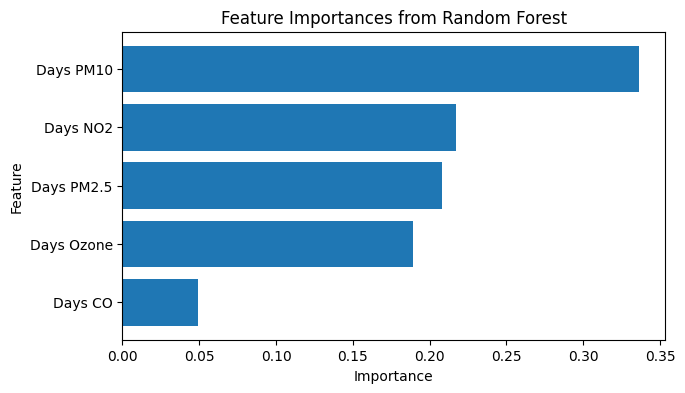

```python
from sklearn.ensemble import RandomForestRegressor
from sklearn.model_selection import train_test_split
import matplotlib.pyplot as plt

X = merged_data_all_years[pollution_features]
y = merged_data_all_years["CURRENT PREVALENCE"]

X_train, X_test, y_train, y_test = train_test_split(X, y, test_size=0.2, random_state=42)

# Define the Random Forest Model
rf_model = RandomForestRegressor(n_estimators=100, random_state=42)
rf_model.fit(X_train, y_train)

# Make prediction and evaluate the model
y_pred = rf_model.predict(X_test)
r2 = r2_score(y_test, y_pred)
mse = mean_squared_error(y_test, y_pred)

# Print model preformance
print(f"R² Score: {r2}")
print(f"Mean Squared Error: {mse}")

# Output feature importance
feature_importances = pd.DataFrame({
    "Feature": pollution_features,
    "Importance": rf_model.feature_importances_
}).sort_values(by="Importance", ascending=False)

print("Feature Importances:")
print(feature_importances)

plt.figure(figsize=(7, 4))
plt.barh(feature_importances["Feature"], feature_importances["Importance"])
plt.gca().invert_yaxis()
plt.title("Feature Importances from Random Forest")
plt.xlabel("Importance")
plt.ylabel("Feature")
plt.show()
```

The Random Forest model demonstrated a different perspective on the relationship, allowing for nonlinear interactions and more complex patterns. However, the resulting R² score of approximately -0.12 indicates that even this more advanced modeling approach fails to reliably explain the variation in asthma prevalence based on the provided pollution metrics. While certain features (e.g., Days PM10, NO2, PM2.5) emerged as relatively more influential, their combined effect remains weak.

**Interpreting the Random Forest Results**:

- **Limited Predictive Power**: The negative R² and high MSE values suggest that, despite the Random Forest’s ability to capture nonlinearities, pollution days alone do not form a strong predictive baseline for asthma prevalence. This aligns with the earlier linear and lagged analyses, reinforcing the notion that air pollution metrics, in isolation, offer limited explanatory power.
- **Influence of Individual Pollutants**: Even though the model identified PM10 and NO2 as more important than Ozone or CO, their importance does not translate into predictive accuracy. In other words, being “important” within the model does not mean the model can effectively predict asthma rates.
- **Complexity of Asthma Prevalence**: These findings are consistent with our earlier hypotheses. Asthma prevalence likely depends on a broad array of factors—such as socioeconomic conditions, healthcare access, genetic predispositions, or indoor air quality—that are not captured by our current dataset. The inability of linear and nonlinear models alike to achieve meaningful explanatory power strongly suggests that other variables may play a dominant role.

These results are in line with the previous regression and lagged analyses. Whether linear or nonlinear, the models are unable to capture a strong, reliable relationship. This indicates that focusing solely on pollution metrics may not be sufficient to understand the factors influencing asthma prevalence. A more comprehensive approach that includes additional environmental variables, socioeconomic data, healthcare availability, and potentially temporal or seasonal factors may be needed to uncover meaningful patterns.

In the conclusion section, we will synthesize all these findings and discuss potential future directions for research and analysis.

```python
from sklearn.model_selection import cross_val_score, KFold
import numpy as np

# Define K-Fold cross-validation
kf = KFold(n_splits=5, shuffle=True, random_state=42)

# Evaluate the Random Forest model using cross-validation with R² scoring
cv_scores = cross_val_score(rf_model, X, y, cv=kf, scoring='r2')

# Print cross-validation results for R² scores
print(f"Cross-Validation R² Scores: {cv_scores}")
print(f"Mean R² Score: {np.mean(cv_scores)}")
print(f"Standard Deviation of R² Scores: {np.std(cv_scores)}")

# Evaluate the Random Forest model using cross-validation with Mean Squared Error (MSE)
cv_mse_scores = -cross_val_score(rf_model, X, y, cv=kf, scoring='neg_mean_squared_error')
print(f"Cross-Validation MSE Scores: {cv_mse_scores}")
print(f"Mean MSE: {np.mean(cv_mse_scores)}")
print(f"Standard Deviation of MSE Scores: {np.std(cv_mse_scores)}")
```

```
Cross-Validation R² Scores: [-0.10554288 -0.59256363 -1.83642913  0.45207635 -0.64447048]
Mean R² Score: -0.5453859535056351
Standard Deviation of R² Scores: 0.7572620320802973
Cross-Validation MSE Scores: [38.52478882 18.97783055 31.03287882  4.82716209 21.8188343 ]
Mean MSE: 23.03629891454546
Standard Deviation of MSE Scores: 11.431226173099553
```

Similarly, the mean MSE score of 23.03, along with its standard deviation of 11.43, highlights variability in prediction errors. These findings align with previous analyses, indicating that air pollution alone is unlikely to be a strong predictor of asthma prevalence, and other factors may play a more prominent role in influencing asthma rates.

## **Conclusion**

This analysis set out to explore whether air pollution metrics could help explain variations in asthma prevalence across U.S. counties. By applying three different modeling approaches—linear regression, a non-linear Random Forest model, and a lagged exposure analysis—we consistently found that these pollution indicators alone offered limited predictive power. Key findings include:

Taken together, these results imply that the relationship between air pollution and asthma prevalence may be minimal or far more complex than simple metric-to-outcome modeling can capture. Factors beyond outdoor pollution—such as socioeconomic conditions, healthcare accessibility, demographic variables, indoor air quality, and genetic predispositions—may exert stronger or interacting influences on asthma prevalence. To gain a more comprehensive understanding, future research should consider incorporating a broader range of variables, employing more nuanced modeling techniques, and exploring additional data sources.